# Signatures of positive selection at drug resistance loci in *Mycobacterium tuberculosis*

Tatum Mortimer

August 07, 2017

### Data set description

We downloaded sequencing read data from two large surveys of drug resistant *M. tuberculosis* in Russia (Casali et al. 2014) and South Africa (Cohen et al. 2015). Reads were mapped to *M. tuberculosis* H37Rv using our validated reference guided assembly pipeline (https://github.com/pepperell-lab/RGAPepPipe/). We removed isolates with mean coverage less than 20X, isolates with percentage of the genome covered at 10X less than 90%, isolates where a majority of reads did not map to H37Rv, and isolates where greater than 10% of sites were unknown after mapping. The final dataset contains 1161 M. tuberculosis isolates, primarily from lineage 2 and lineage 4. The alignment was masked to remove repetitive regions including PE/PPE genes.

### Phylogenetic analysis

Phylogenetic analysis was performed using FastTree v 2.1.9 (compiled with the double precision option).

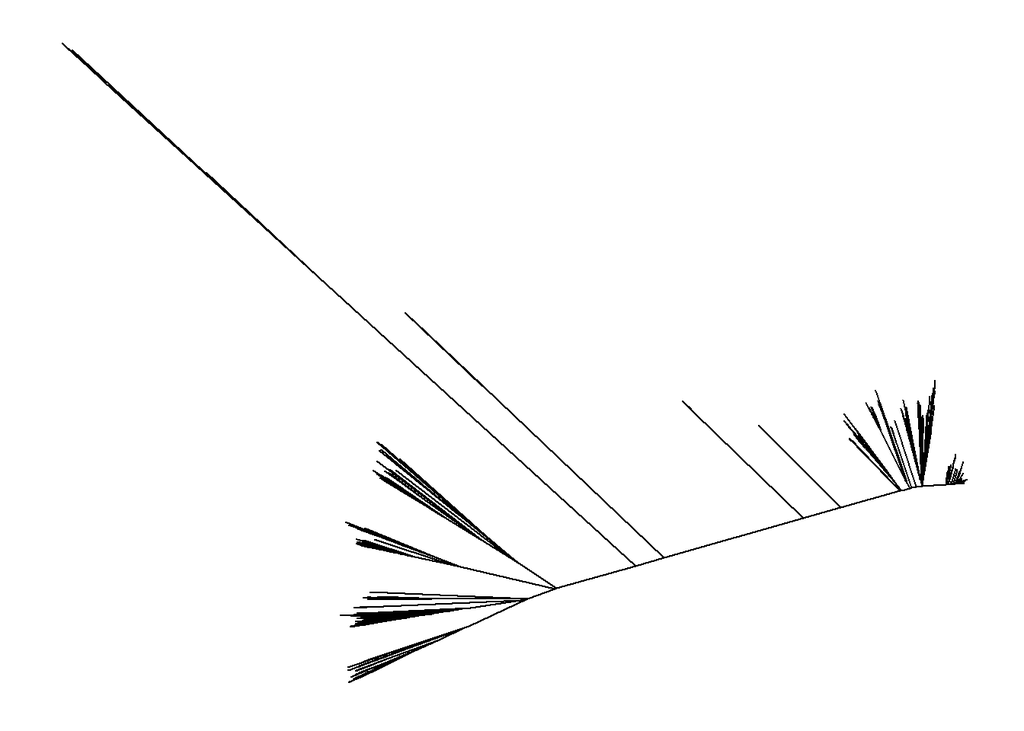

The majority of the isolates in this dataset are from lineage 2 (n = 667) or lineage 4 (n = 481). There are a few isolates from lineage 1 and lineage 3.

### Frequency of drug resistance in dataset

| Drug | Resistant | Susceptible | Unknown |
| --- | --- | --- | --- |
| INH | 690 | 382 | 89 |
| STR | 617 | 457 | 87 |
| RIF | 576 | 498 | 87 |
| EMB | 350 | 689 | 122 |
| PZA | 245 | 775 | 141 |
| OFL | 185 | 453 | 523 |
| PRO | 179 | 260 | 722 |
| CAP | 113 | 479 | 569 |
| MOX | 105 | 296 | 760 |
| Et | 66 | 77 | 1018 |
| AMI | 60 | 389 | 712 |
| K | 53 | 139 | 969 |

### Size of genetic target for drug resistance

Drug resistance mutations have been described for resistance to the most commonly used drugs. The TB Drug Resistance Mutation Database (https://tbdreamdb.ki.se/Info/) has a downloadable list of genes and specific mutations associated with drug resistance. I obtained the database to examine the size of the genetic target for resistance mutations in each drug. It is possible that some drug resistance mechanisms are more well studied than others (i.e. first line drugs), so the number of mutations reported in the database may not be strictly related to the size of the genetic target.

#### Counts of genes and mutations known to cause drug resistance

| Drug | unique_genes | total_mutations |
| --- | --- | --- |
| INH | 22 | 386 |
| EMB | 13 | 213 |
| SM | 3 | 64 |
| ETH | 3 | 28 |
| RIF | 2 | 137 |
| FLQ | 2 | 35 |
| AMI | 2 | 34 |
| PZA | 1 | 278 |
| PAS | 1 | 2 |

#### Counts of mutations per drug resistance associated gene

| GeneName | total_mutations |
| --- | --- |
| katG | 226 |
| pncA | 195 |
| embB | 117 |
| ahpC | 31 |
| embC | 28 |
| tlyA | 28 |
| embR | 25 |
| rrs | 24 |
| ethA | 23 |
| gid | 22 |
| gyrB | 15 |
| fabG1 | 13 |
| inhA | 13 |
| rpsL | 13 |
| gyrA | 12 |
| embA | 11 |
| oxyR | 8 |
| kasA | 7 |
| ndh | 5 |
| iniA | 4 |
| fbpC | 3 |
| iniB | 3 |
| Rv0340 | 3 |
| Rv1592c | 3 |
| iniC | 2 |
| nat | 2 |
| rmlD | 2 |
| srmR homolog | 2 |
| thyA | 2 |
| accD6 | 1 |
| efpA | 1 |
| fabD | 1 |
| fadE24 | 1 |
| furA | 1 |
| manB | 1 |
| rpoB | 1 |
| Rv1772 | 1 |
| Rv3124 | 1 |
| Rv3125c | 1 |
| Rv3126 | 1 |

### Population genetics of *M. tuberculosis* genes

The whole genome alignment of *M. tuberculosis* isolates was divided into genewise alignments based on the annotation of *M. tuberculosis* H37Rv. Egglib was used to calculate neutrality and diversity statistics for these genewise alignments.

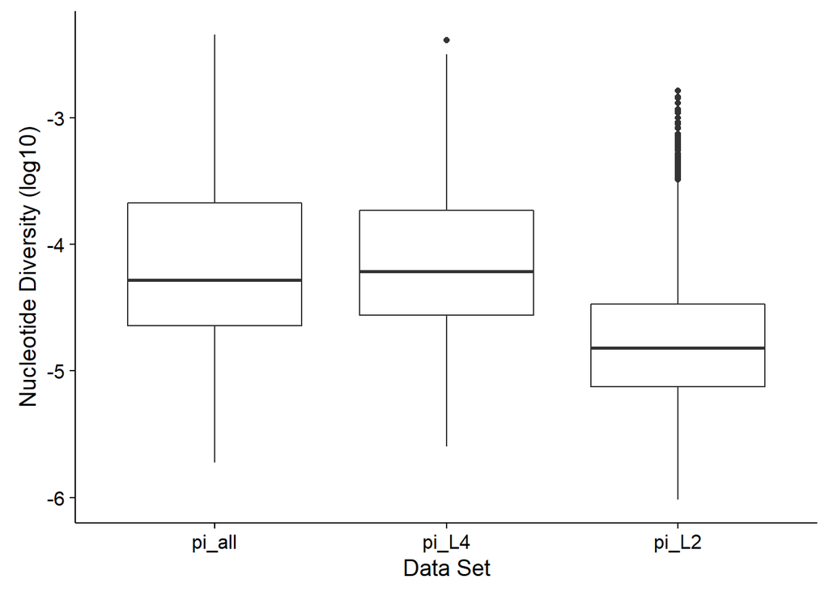

Diversity Statistics of Resistance Genes in All Isolates

|  | gene | theta_all | pi_all | td_all | pr_pi_all | pr_theta_all | pr_TD_all |
| --- | --- | --- | --- | --- | --- | --- | --- |
| 47 | iniA | 0.00082 | 0.00010 | -1.796 | 0.644 | 0.328 | 0.221 |
| 278 | kasA | 0.00063 | 0.00018 | -1.190 | 0.733 | 0.185 | 0.708 |
| 342 | tlyA | 0.00172 | 0.00003 | -1.927 | 0.372 | 0.890 | 0.128 |
| 724 | gyrB | 0.00182 | 0.00007 | -2.348 | 0.580 | 0.913 | 0.006 |
| 734 | gyrA | 0.00201 | 0.00030 | -2.172 | 0.814 | 0.941 | 0.030 |
| 772 | accD6 | 0.00119 | 0.00052 | -1.067 | 0.902 | 0.632 | 0.779 |
| 811 | gid | 0.00742 | 0.00203 | -1.853 | 0.997 | 0.999 | 0.175 |
| 841 | ethA | 0.00482 | 0.00017 | -2.552 | 0.722 | 0.998 | 0.001 |
| 849 | ethR | 0.00141 | 0.00007 | -1.673 | 0.583 | 0.774 | 0.315 |
| 861 | furA | 0.00118 | 0.00027 | -1.119 | 0.799 | 0.626 | 0.730 |
| 1008 | Rv0340 | 0.00170 | 0.00047 | -1.275 | 0.887 | 0.884 | 0.648 |
| 1111 | pncA | 0.01737 | 0.00090 | -2.573 | 0.969 | 1.000 | 0.000 |
| 1144 | fabG1 | 0.00123 | 0.00008 | -1.651 | 0.599 | 0.663 | 0.327 |
| 1217 | Rv0678 | 0.00132 | 0.00003 | -1.538 | 0.367 | 0.721 | 0.449 |
| 1324 | rmlD | 0.00086 | 0.00020 | -1.281 | 0.752 | 0.360 | 0.629 |
| 1462 | eis | 0.00076 | 0.00005 | -1.645 | 0.513 | 0.276 | 0.338 |
| 1587 | embA | 0.00088 | 0.00023 | -1.739 | 0.769 | 0.380 | 0.254 |
| 1588 | embB | 0.00171 | 0.00022 | -2.246 | 0.767 | 0.887 | 0.013 |
| 1589 | embC | 0.00136 | 0.00008 | -2.372 | 0.589 | 0.744 | 0.004 |
| 1596 | embR | 0.00101 | 0.00004 | -1.825 | 0.461 | 0.494 | 0.195 |
| 1705 | Rv1772 | 0.00084 | 0.00005 | -1.031 | 0.503 | 0.347 | 0.806 |
| 1743 | iniB | 0.00038 | 0.00001 | -1.423 | 0.071 | 0.073 | 0.537 |
| 1744 | iniC | 0.00124 | 0.00005 | -2.058 | 0.486 | 0.669 | 0.062 |
| 1779 | katG | 0.00151 | 0.00027 | -1.976 | 0.796 | 0.816 | 0.098 |
| 1841 | mshA | 0.00100 | 0.00041 | -1.196 | 0.864 | 0.481 | 0.707 |
| 1893 | fabD | 0.00076 | 0.00002 | -1.530 | 0.264 | 0.282 | 0.458 |
| 2065 | inhA | 0.00113 | 0.00006 | -1.666 | 0.556 | 0.593 | 0.317 |
| 2301 | thyA | 0.00199 | 0.00036 | -1.686 | 0.844 | 0.939 | 0.310 |
| 2314 | fadE24 | 0.00112 | 0.00003 | -2.003 | 0.360 | 0.580 | 0.085 |
| 2465 | rpsA | 0.00118 | 0.00044 | -1.309 | 0.876 | 0.623 | 0.617 |
| 2665 | nat | 0.00108 | 0.00021 | -1.415 | 0.758 | 0.549 | 0.552 |
| 2757 | rrs | 0.00361 | 0.00048 | -2.069 | 0.888 | 0.996 | 0.058 |
| 2769 | folC | 0.00143 | 0.00012 | -2.021 | 0.662 | 0.784 | 0.076 |
| 2785 | rpoB | 0.00183 | 0.00030 | -2.185 | 0.818 | 0.915 | 0.025 |
| 2823 | rpsL | 0.00210 | 0.00126 | -0.666 | 0.988 | 0.950 | 0.914 |
| 3018 | rplC | 0.00140 | 0.00007 | -1.680 | 0.568 | 0.771 | 0.313 |
| 3093 | ahpC | 0.00067 | 0.00002 | -1.264 | 0.200 | 0.209 | 0.672 |
| 3107 | fbpC | 0.00064 | 0.00025 | -0.959 | 0.784 | 0.191 | 0.826 |
| 3135 | efpA | 0.00049 | 0.00001 | -1.645 | 0.097 | 0.110 | 0.333 |
| 3500 | ndh | 0.00104 | 0.00007 | -1.879 | 0.574 | 0.516 | 0.154 |

I additionally calculated diversity statistics for lineage 2 and lineage 4 separately to remove any effect that lineage structure had on the statistics.

Diversity Statistics of Resistance Genes in Lineage 2

|  | gene | theta_L2 | pi_L2 | td_L2 | pr_pi_L2 | pr_theta_L2 | pr_TD_L2 |
| --- | --- | --- | --- | --- | --- | --- | --- |
| 47 | iniA | 0.00029 | 0.00001 | -1.494 | 0.445 | 0.577 | 0.080 |
| 278 | kasA | 0.00011 | 0.00000 | -0.837 | 0.268 | 0.284 | 0.497 |
| 342 | tlyA | 0.00019 | 0.00000 | -0.837 | 0.317 | 0.395 | 0.564 |
| 725 | gyrB | 0.00056 | 0.00002 | -1.867 | 0.689 | 0.880 | 0.011 |
| 735 | gyrA | 0.00080 | 0.00006 | -2.073 | 0.893 | 0.954 | 0.004 |
| 773 | accD6 | 0.00000 | 0.00000 | NA | 0.124 | 0.124 | 0.807 |
| 812 | gid | 0.00146 | 0.00016 | -1.652 | 0.954 | 0.993 | 0.039 |
| 842 | ethA | 0.00211 | 0.00015 | -2.268 | 0.951 | 0.998 | 0.001 |
| 850 | ethR | 0.00065 | 0.00003 | -1.317 | 0.767 | 0.919 | 0.183 |
| 862 | furA | 0.00000 | 0.00000 | NA | 0.124 | 0.124 | 0.814 |
| 1009 | Rv0340 | 0.00026 | 0.00002 | -0.783 | 0.718 | 0.523 | 0.655 |
| 1112 | pncA | 0.01429 | 0.00117 | -2.520 | 0.998 | 1.000 | 0.000 |
| 1145 | fabG1 | 0.00038 | 0.00004 | -1.053 | 0.820 | 0.718 | 0.404 |
| 1218 | Rv0678 | 0.00057 | 0.00004 | -1.090 | 0.820 | 0.883 | 0.388 |
| 1326 | rmlD | 0.00000 | 0.00000 | NA | 0.124 | 0.124 | 0.844 |
| 1464 | eis | 0.00047 | 0.00008 | -1.269 | 0.919 | 0.814 | 0.221 |
| 1589 | embA | 0.00030 | 0.00010 | -1.262 | 0.929 | 0.590 | 0.225 |
| 1590 | embB | 0.00064 | 0.00020 | -1.565 | 0.963 | 0.917 | 0.066 |
| 1591 | embC | 0.00039 | 0.00001 | -1.943 | 0.533 | 0.729 | 0.008 |
| 1598 | embR | 0.00024 | 0.00004 | -0.982 | 0.828 | 0.495 | 0.425 |
| 1707 | Rv1772 | 0.00091 | 0.00009 | -1.053 | 0.923 | 0.967 | 0.407 |
| 1745 | iniB | 0.00021 | 0.00001 | -1.114 | 0.473 | 0.433 | 0.346 |
| 1746 | iniC | 0.00019 | 0.00002 | -1.065 | 0.636 | 0.405 | 0.399 |
| 1780 | katG | 0.00058 | 0.00002 | -1.916 | 0.743 | 0.892 | 0.009 |
| 1842 | mshA | 0.00020 | 0.00002 | -1.041 | 0.705 | 0.413 | 0.413 |
| 1894 | fabD | 0.00000 | 0.00000 | NA | 0.124 | 0.124 | 0.881 |
| 2066 | inhA | 0.00070 | 0.00004 | -1.438 | 0.852 | 0.934 | 0.116 |
| 2302 | thyA | 0.00089 | 0.00008 | -1.517 | 0.917 | 0.966 | 0.070 |
| 2315 | fadE24 | 0.00010 | 0.00000 | -0.837 | 0.260 | 0.270 | 0.497 |
| 2467 | rpsA | 0.00029 | 0.00002 | -1.268 | 0.723 | 0.577 | 0.225 |
| 2669 | nat | 0.00033 | 0.00001 | -1.139 | 0.418 | 0.642 | 0.267 |
| 2760 | rrs | 0.00324 | 0.00058 | -1.973 | 0.991 | 0.999 | 0.007 |
| 2772 | folC | 0.00096 | 0.00006 | -1.936 | 0.890 | 0.971 | 0.008 |
| 2788 | rpoB | 0.00105 | 0.00016 | -2.131 | 0.953 | 0.977 | 0.002 |
| 2826 | rpsL | 0.00075 | 0.00146 | 1.092 | 1.000 | 0.945 | 0.751 |
| 3021 | rplC | 0.00000 | 0.00000 | NA | 0.124 | 0.124 | 0.957 |
| 3096 | ahpC | 0.00048 | 0.00001 | -1.139 | 0.516 | 0.827 | 0.292 |
| 3110 | fbpC | 0.00014 | 0.00001 | -0.801 | 0.474 | 0.318 | 0.640 |
| 3138 | efpA | 0.00018 | 0.00000 | -1.139 | 0.310 | 0.383 | 0.267 |
| 3503 | ndh | 0.00061 | 0.00004 | -1.656 | 0.831 | 0.902 | 0.039 |

Diversity Statistics of Resistance Genes in Lineage 4

|  | gene | theta_L4 | pi_L4 | td_L4 | pr_pi_L4 | pr_theta_L4 | pr_TD_L4 |
| --- | --- | --- | --- | --- | --- | --- | --- |
| 47 | iniA | 0.00054 | 0.00021 | -1.167 | 0.785 | 0.295 | 0.642 |
| 278 | kasA | 0.00047 | 0.00035 | -0.432 | 0.866 | 0.235 | 0.895 |
| 343 | tlyA | 0.00155 | 0.00007 | -1.913 | 0.551 | 0.934 | 0.093 |
| 722 | gyrB | 0.00140 | 0.00013 | -2.221 | 0.700 | 0.895 | 0.012 |
| 732 | gyrA | 0.00125 | 0.00052 | -1.452 | 0.934 | 0.846 | 0.420 |
| 770 | accD6 | 0.00105 | 0.00007 | -1.797 | 0.559 | 0.732 | 0.152 |
| 809 | gid | 0.00573 | 0.00110 | -2.011 | 0.991 | 0.999 | 0.052 |
| 839 | ethA | 0.00292 | 0.00017 | -2.466 | 0.744 | 0.995 | 0.001 |
| 847 | ethR | 0.00068 | 0.00013 | -1.156 | 0.703 | 0.438 | 0.665 |
| 859 | furA | 0.00100 | 0.00059 | -0.590 | 0.949 | 0.700 | 0.881 |
| 1004 | Rv0340 | 0.00165 | 0.00086 | -0.868 | 0.982 | 0.946 | 0.750 |
| 1107 | pncA | 0.00715 | 0.00050 | -2.409 | 0.927 | 1.000 | 0.003 |
| 1140 | fabG1 | 0.00119 | 0.00013 | -1.637 | 0.696 | 0.821 | 0.262 |
| 1213 | Rv0678 | 0.00089 | 0.00003 | -1.387 | 0.270 | 0.619 | 0.451 |
| 1319 | rmlD | 0.00065 | 0.00038 | -0.647 | 0.885 | 0.404 | 0.872 |
| 1457 | eis | 0.00037 | 0.00001 | -1.387 | 0.112 | 0.162 | 0.466 |
| 1582 | embA | 0.00041 | 0.00003 | -1.936 | 0.272 | 0.187 | 0.081 |
| 1583 | embB | 0.00144 | 0.00028 | -2.137 | 0.829 | 0.906 | 0.023 |
| 1584 | embC | 0.00081 | 0.00012 | -2.052 | 0.693 | 0.556 | 0.039 |
| 1591 | embR | 0.00076 | 0.00002 | -1.769 | 0.269 | 0.514 | 0.167 |
| 1700 | Rv1772 | 0.00000 | 0.00000 | NA | 0.032 | 0.032 | 0.965 |
| 1738 | iniB | 0.00022 | 0.00001 | -1.176 | 0.075 | 0.084 | 0.599 |
| 1739 | iniC | 0.00080 | 0.00006 | -1.858 | 0.503 | 0.545 | 0.121 |
| 1774 | katG | 0.00109 | 0.00007 | -2.217 | 0.563 | 0.757 | 0.012 |
| 1836 | mshA | 0.00092 | 0.00015 | -1.736 | 0.722 | 0.644 | 0.190 |
| 1887 | fabD | 0.00069 | 0.00005 | -1.480 | 0.465 | 0.450 | 0.406 |
| 2059 | inhA | 0.00055 | 0.00008 | -1.216 | 0.605 | 0.305 | 0.586 |
| 2295 | thyA | 0.00094 | 0.00059 | -0.645 | 0.949 | 0.651 | 0.873 |
| 2308 | fadE24 | 0.00095 | 0.00005 | -1.955 | 0.473 | 0.662 | 0.072 |
| 2459 | rpsA | 0.00082 | 0.00020 | -1.504 | 0.777 | 0.562 | 0.380 |
| 2658 | nat | 0.00087 | 0.00047 | -0.795 | 0.918 | 0.601 | 0.844 |
| 2750 | rrs | 0.00391 | 0.00018 | -2.410 | 0.758 | 0.998 | 0.002 |
| 2762 | folC | 0.00081 | 0.00020 | -1.514 | 0.773 | 0.553 | 0.369 |
| 2778 | rpoB | 0.00118 | 0.00015 | -2.279 | 0.721 | 0.813 | 0.007 |
| 2816 | rpsL | 0.00237 | 0.00084 | -1.183 | 0.980 | 0.988 | 0.595 |
| 3011 | rplC | 0.00136 | 0.00015 | -1.621 | 0.729 | 0.881 | 0.276 |
| 3086 | ahpC | 0.00050 | 0.00003 | -1.142 | 0.305 | 0.262 | 0.676 |
| 3100 | fbpC | 0.00029 | 0.00044 | 0.630 | 0.911 | 0.118 | 0.931 |
| 3127 | efpA | 0.00037 | 0.00002 | -1.513 | 0.194 | 0.165 | 0.371 |
| 3492 | ndh | 0.00043 | 0.00010 | -1.233 | 0.644 | 0.199 | 0.579 |

#### Tajima’s D:

Minimum: -2.573  
1st Quartile: -1.759  
Median: -1.505  
Mean: -1.417  
3rd Quartile: -1.129  
Maximum: 2.211

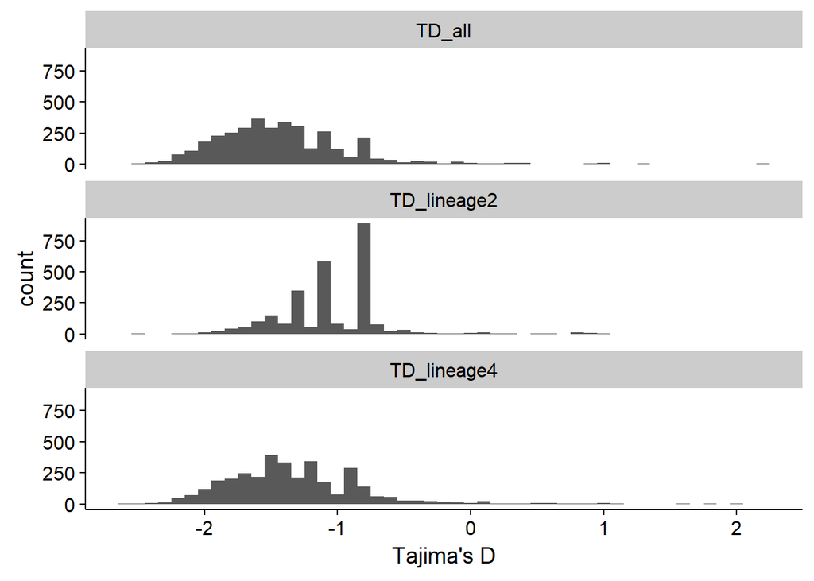

Previously, we have observed that there is a correlation between Tajima’s D and gene length in *M. tuberculosis*, which we see in this dataset as well. This pattern also occurs in simulated data of linked genomes when a proportion of sites is under purifying selection.

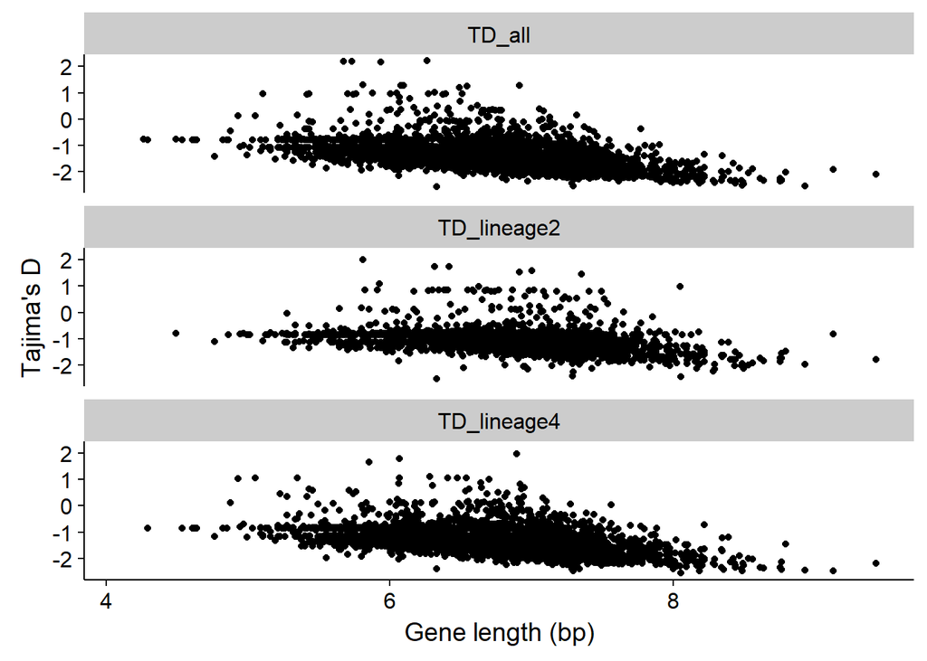

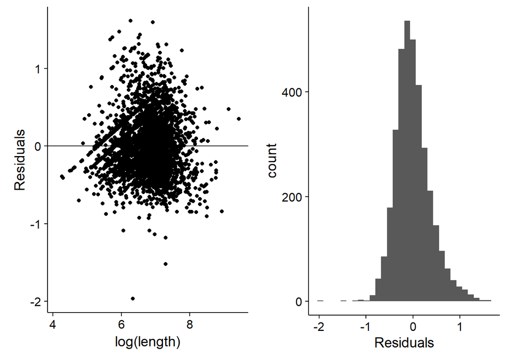

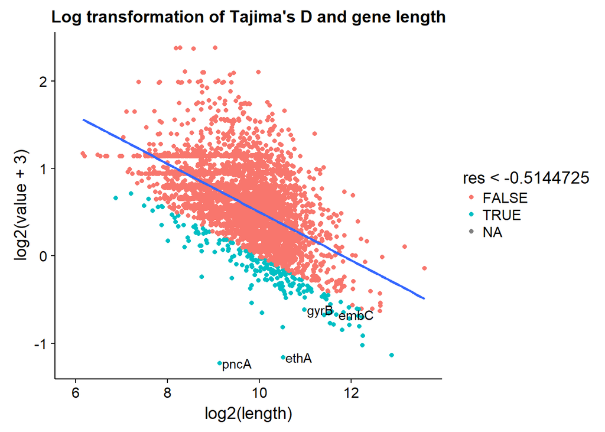

Tajima’s D and residual values of drug resistance loci

|  | gene | length | variable | value | res | pr_ted_res |
| --- | --- | --- | --- | --- | --- | --- |
| 4 | gyrB | 2028 | TD_all | -2.3476442 | -0.8476717 | 0.0041528 |
| 5 | gyrA | 2517 | TD_all | -2.1720538 | -0.4179571 | 0.0966224 |
| 127 | fbpC | 1023 | TD_all | -0.9590599 | 0.5259136 | 0.8867663 |
| 328 | Rv0340 | 540 | TD_all | -1.2750251 | 0.0293717 | 0.5675526 |
| 329 | iniB | 1440 | TD_all | -1.4233312 | 0.2894181 | 0.7857143 |
| 330 | iniA | 1923 | TD_all | -1.7959622 | 0.0153529 | 0.5550941 |
| 331 | iniC | 1482 | TD_all | -2.0584833 | -0.4429790 | 0.0844408 |
| 467 | mshA | 1443 | TD_all | -1.1962499 | 0.4843649 | 0.8737542 |
| 626 | rpoB | 3519 | TD_all | -2.1852268 | -0.3079365 | 0.1816168 |
| 637 | Rv0678 | 498 | TD_all | -1.5382831 | -0.2417136 | 0.2513843 |
| 641 | rpsL | 375 | TD_all | -0.6663353 | 0.3204991 | 0.8042636 |
| 661 | rplC | 654 | TD_all | -1.6798269 | -0.2803670 | 0.2117940 |
| 1170 | embR | 1167 | TD_all | -1.8250013 | -0.2183301 | 0.2760244 |
| 1219 | rrs | 1537 | TD_all | -2.0693099 | -0.4451852 | 0.0833333 |
| 1379 | fabG1 | 744 | TD_all | -1.6511673 | -0.1981496 | 0.3003876 |
| 1380 | inhA | 810 | TD_all | -1.6659974 | -0.1803266 | 0.3186600 |
| 1511 | rpsA | 1446 | TD_all | -1.3093252 | 0.3917899 | 0.8372093 |
| 1574 | tlyA | 807 | TD_all | -1.9266137 | -0.4953932 | 0.0600775 |
| 1638 | Rv1772 | 312 | TD_all | -1.0312813 | 0.0020752 | 0.5398671 |
| 1702 | ndh | 1392 | TD_all | -1.8787595 | -0.2158368 | 0.2801772 |
| 1757 | katG | 2223 | TD_all | -1.9758337 | -0.1604720 | 0.3383167 |
| 1758 | furA | 444 | TD_all | -1.1188652 | 0.0766185 | 0.6168328 |
| 1887 | pncA | 561 | TD_all | -2.5726035 | -1.9683965 | 0.0002769 |
| 2082 | fabD | 909 | TD_all | -1.5300869 | 0.0054626 | 0.5442968 |
| 2085 | kasA | 1251 | TD_all | -1.1904369 | 0.4322714 | 0.8552049 |
| 2087 | accD6 | 1422 | TD_all | -1.0672078 | 0.5782268 | 0.9000554 |
| 2241 | eis | 1209 | TD_all | -1.6448613 | 0.0015009 | 0.5387597 |
| 2252 | ahpC | 588 | TD_all | -1.2635649 | 0.0727631 | 0.6126800 |
| 2270 | folC | 1464 | TD_all | -2.0214732 | -0.3922102 | 0.1101883 |
| 2566 | thyA | 792 | TD_all | -1.6858720 | -0.2109122 | 0.2846069 |
| 2634 | efpA | 1593 | TD_all | -1.6450742 | 0.1108761 | 0.6542082 |
| 2909 | fadE24 | 1407 | TD_all | -2.0034575 | -0.3816703 | 0.1173865 |
| 3036 | rmlD | 915 | TD_all | -1.2812959 | 0.2336672 | 0.7480620 |
| 3276 | nat | 852 | TD_all | -1.4149138 | 0.0885606 | 0.6328904 |
| 3489 | embC | 3285 | TD_all | -2.3715950 | -0.7099830 | 0.0127353 |
| 3490 | embA | 3285 | TD_all | -1.7388492 | 0.2949913 | 0.7887597 |
| 3491 | embB | 3297 | TD_all | -2.2455355 | -0.4447757 | 0.0836102 |
| 3546 | ethA | 1470 | TD_all | -2.5522603 | -1.5185361 | 0.0005537 |
| 3547 | ethR | 651 | TD_all | -1.6733215 | -0.2751022 | 0.2167774 |
| 3607 | gid | 675 | TD_all | -1.8527960 | -0.4704135 | 0.0705980 |

### Comparison of drug resistant and sensitive populations

For each drug where susceptibility information was available, we created alignments of drug resistant and susceptible isolates (isolates with unknown susceptibility were not included). Our hypothesis was that drug resistance conferring genes would have more extreme measures of diversity in drug resistant isolates compared to drug susceptible isolates. We also hypothesized that drug resistance genes would be among Fst outliers using drug resistant and drug susceptible isolates as populations. Genewise pi and theta were calculated using egglib.i We performed these analysis in the whole dataset as well as lineage specific alignments.

### Overall diversity of drug resistant vs. susceptible isolates

```
##
##  Paired t-test
##
## data:  bydrug_stats.wide$resistant and bydrug_stats.wide$susceptible
## t = -2.125, df = 11, p-value = 0.05708
## alternative hypothesis: true difference in means is not equal to 0
## 95 percent confidence interval:
##  -5.777084e-05  1.015129e-06
## sample estimates:
## mean of the differences
##           -2.837785e-05
```

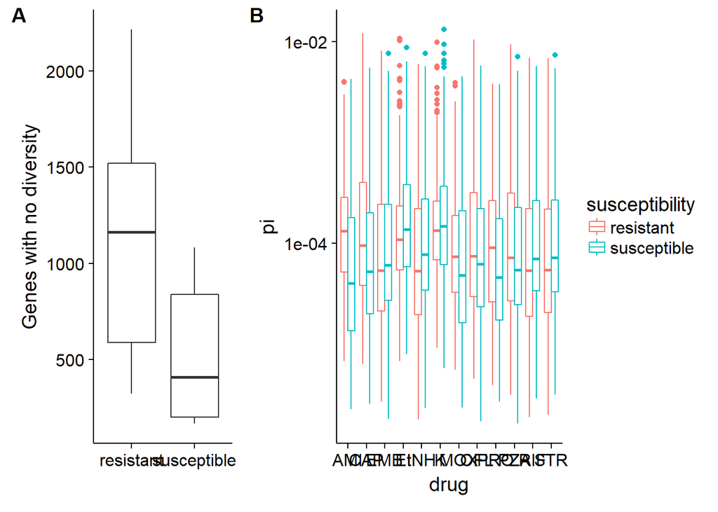

Resistant isolates have more genes with no diversity compared to susceptible isolates. However, among genes with measurable diversity, values between susceptible and resistant isolates are similar.

#### Diversity of drug resistance genes in resistant vs. susceptible isolates

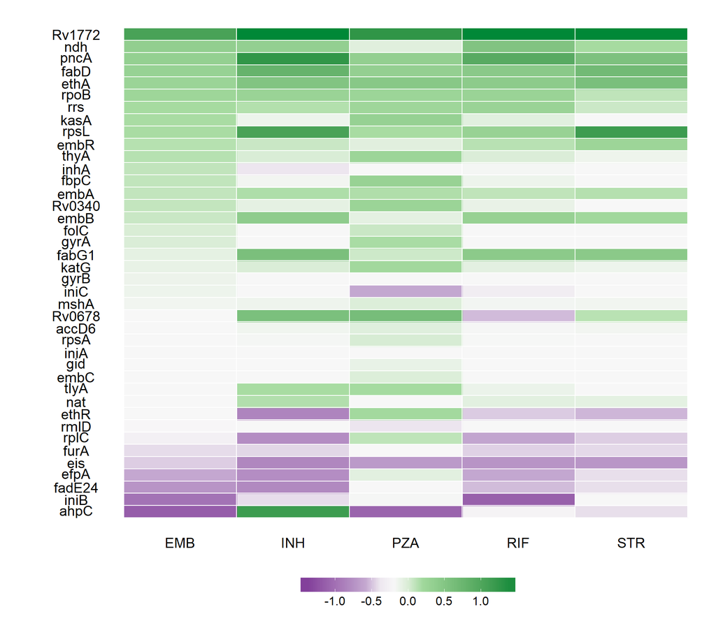

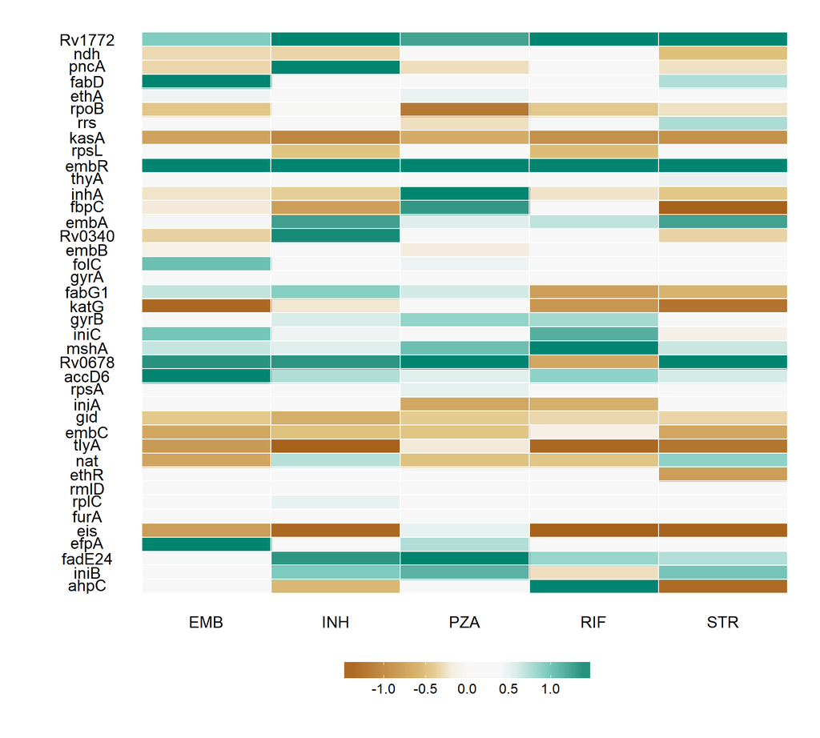

#### Diversity of ribosomal proteins

A recent study in *M. smegmatis* described mutations in ribosomal proteins that conferred multidrug resistance (Gomez et al. 2017). I compared diversity in these genes between resistant and susceptible isolates.

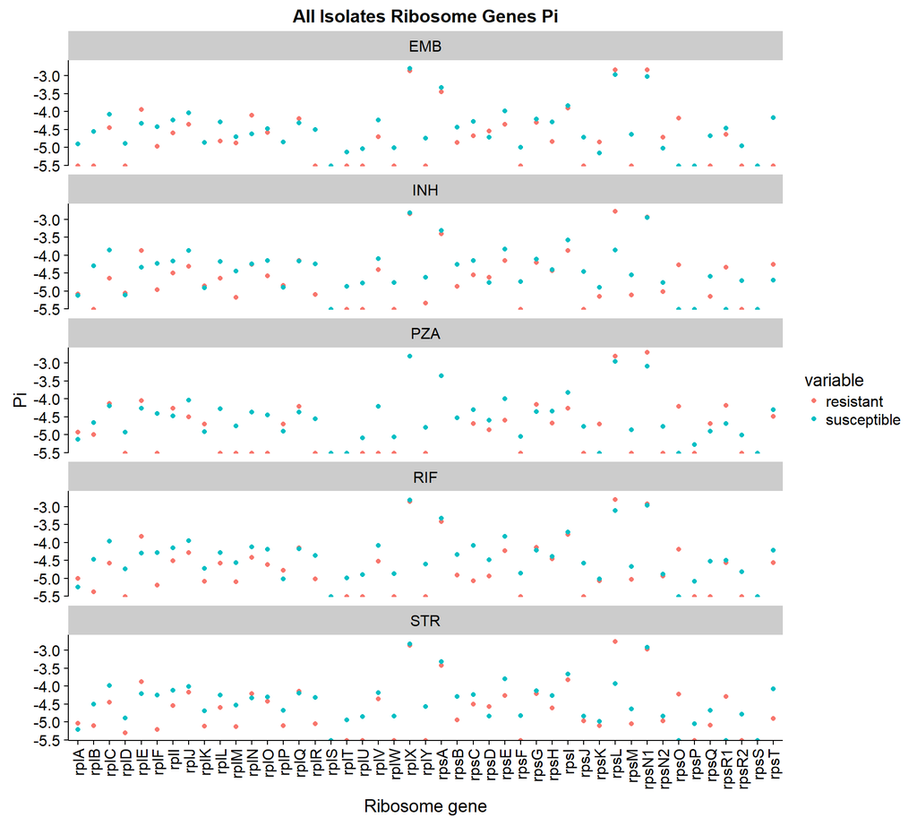

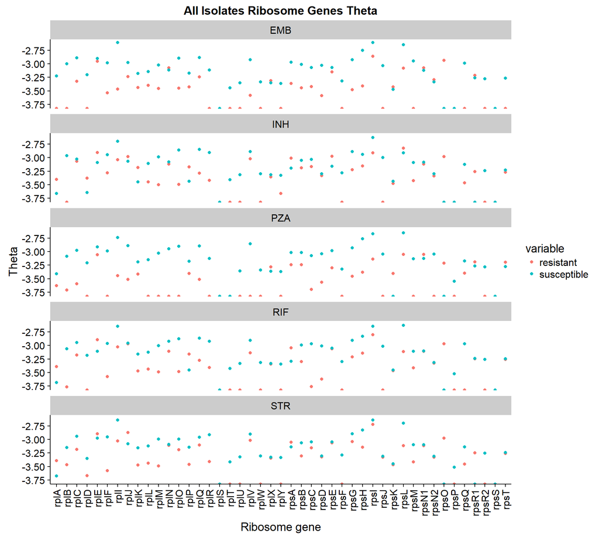

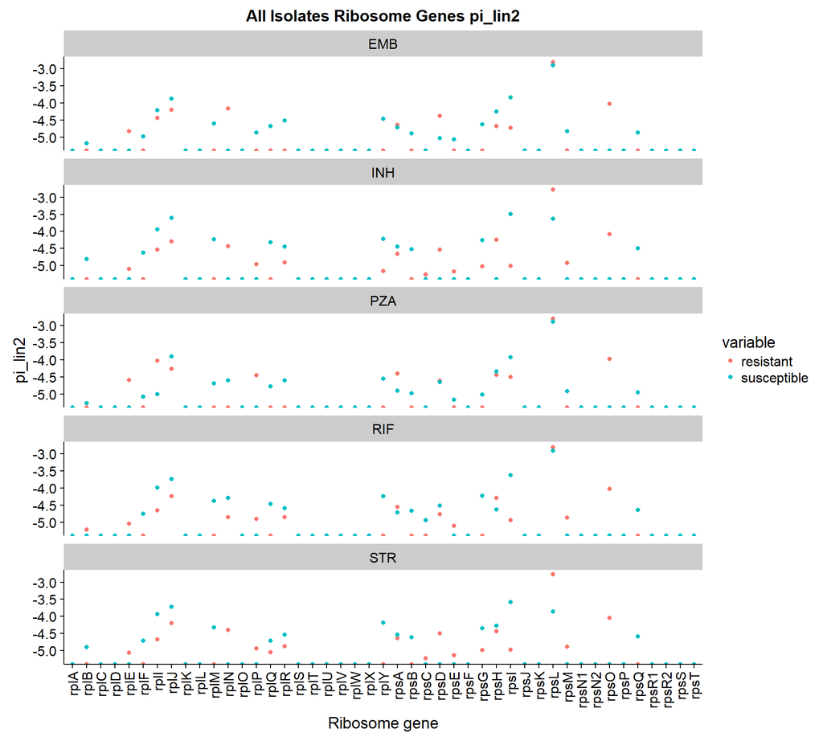

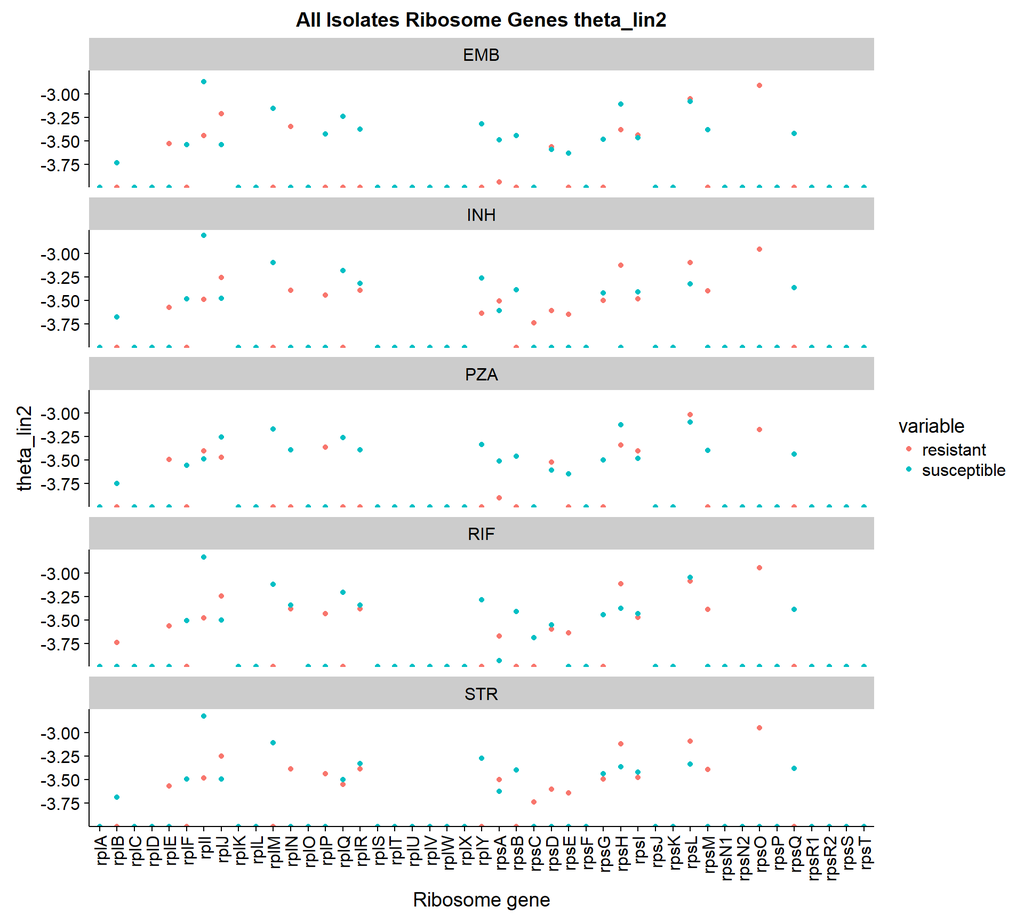

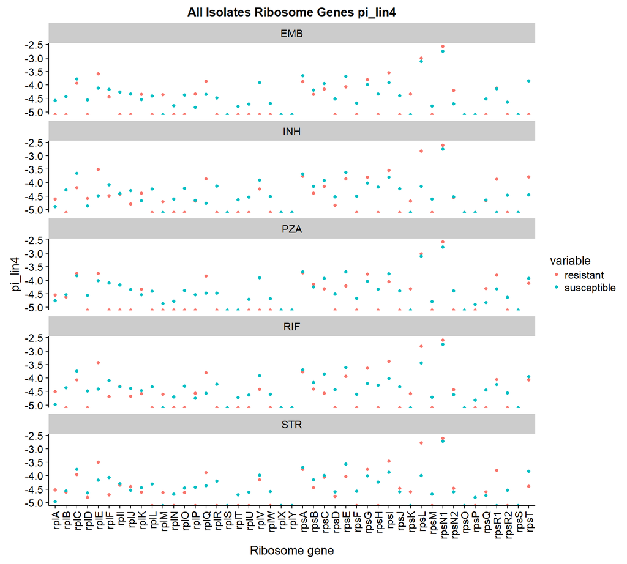

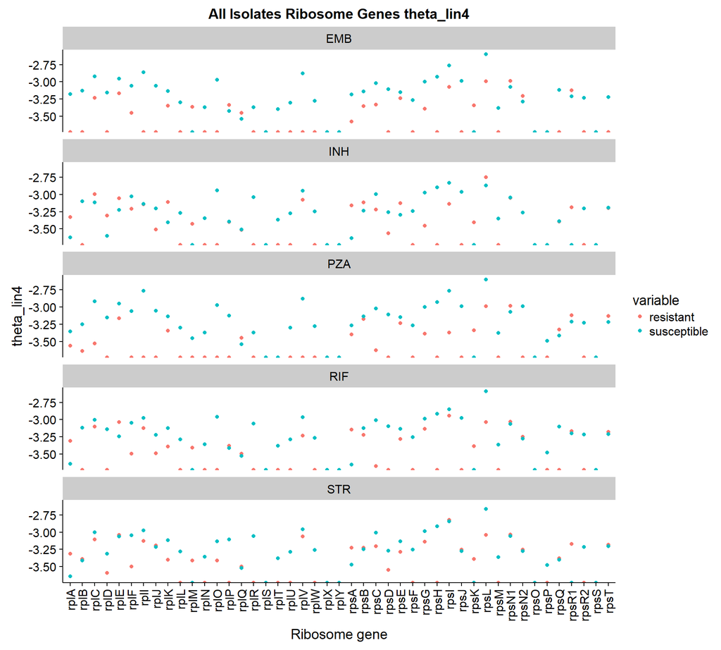

#### Fst outlier analysis

I used vcflib to calculate wcFst for resistant and susceptible populations of each drug. Our hypothesis is that drug resistance genes should contain more Fst outliers than other genes in the M. tb genome.

#### Insertions and Deletions

In addition to SNPs, pilon also calls insertions and deletions from mapped reads. I used emu to normalize the indels in all isolates. Using the normalized indels coded as 0/1 for presence or absence, I performed Fst analysis for resistance to each drug in the whole dataset, as well as lineage 2 and lineage 4.

### Homoplasy

Homoplasy has been previously used to identify drug resistance associated loci in M. tb (Farhat et al. 2013). We identified homoplasies by performing ancestral reconstruction in TreeTime and counting the number of times SNPs arose on the phylogeny. Homoplastic SNPs were significantly enriched in drug resistance genes.

Signatures of selection in known drug resistance genes.

| gene | rv | total_mutations | pr_pi_all | pr_theta_all | pr_ted_res | homoplasy | fst |
| --- | --- | --- | --- | --- | --- | --- | --- |
| katG | Rv1908c | 226 | 0.7964187 | 0.8159780 | 0.3383167 | TRUE | TRUE |
| pncA | Rv2043c | 195 | 0.9691460 | 1.0000000 | 0.0002769 | TRUE | FALSE |
| embB | Rv3795 | 117 | 0.7672176 | 0.8867769 | 0.0836102 | TRUE | TRUE |
| ahpC | Rv2428 | 31 | 0.2000000 | 0.2092287 | 0.6126800 | TRUE | FALSE |
| tlyA | Rv1694 | 28 | 0.3719008 | 0.8898072 | 0.0600775 | FALSE | FALSE |
| embC | Rv3793 | 28 | 0.5892562 | 0.7443526 | 0.0127353 | FALSE | FALSE |
| embR | Rv1267c | 25 | 0.4611570 | 0.4936639 | 0.2760244 | FALSE | FALSE |
| rrs | Rvnr01 | 24 | 0.8878788 | 0.9958678 | 0.0833333 | FALSE | FALSE |
| ethA | Rv3854c | 23 | 0.7217631 | 0.9980716 | 0.0005537 | TRUE | FALSE |
| gid | Rv3919c | 22 | 0.9969697 | 0.9991736 | 0.0705980 | TRUE | FALSE |
| gyrB | Rv0005 | 15 | 0.5798898 | 0.9134986 | 0.0041528 | TRUE | FALSE |
| fabG1 | Rv1483 | 13 | 0.5986226 | 0.6634986 | 0.3003876 | TRUE | FALSE |
| inhA | Rv1484 | 13 | 0.5561983 | 0.5931129 | 0.3186600 | TRUE | FALSE |
| rpsL | Rv0682 | 13 | 0.9876033 | 0.9498623 | 0.8042636 | TRUE | TRUE |
| gyrA | Rv0006 | 12 | 0.8137741 | 0.9407713 | 0.0966224 | TRUE | TRUE |
| embA | Rv3794 | 11 | 0.7685950 | 0.3804408 | 0.7887597 | FALSE | FALSE |
| kasA | Rv2245 | 7 | 0.7330579 | 0.1848485 | 0.8552049 | FALSE | FALSE |
| ndh | Rv1854c | 5 | 0.5741047 | 0.5162534 | 0.2801772 | FALSE | FALSE |
| iniA | Rv0342 | 4 | 0.6440771 | 0.3280992 | 0.5550941 | FALSE | FALSE |
| Rv0340 | Rv0340 | 3 | 0.8865014 | 0.8840220 | 0.5675526 | FALSE | FALSE |
| iniB | Rv0341 | 3 | 0.0713499 | 0.0730028 | 0.7857143 | FALSE | FALSE |
| fbpC | Rv0129c | 3 | 0.7837466 | 0.1914601 | 0.8867663 | FALSE | FALSE |
| rmlD | Rv3266c | 2 | 0.7515152 | 0.3600551 | 0.7480620 | FALSE | FALSE |
| iniC | Rv0343 | 2 | 0.4859504 | 0.6690083 | 0.0844408 | FALSE | FALSE |
| thyA | Rv2764c | 2 | 0.8435262 | 0.9385675 | 0.2846069 | FALSE | FALSE |
| nat | Rv3566c | 2 | 0.7578512 | 0.5494490 | 0.6328904 | FALSE | FALSE |
| accD6 | Rv2247 | 1 | 0.9024793 | 0.6322314 | 0.9000554 | FALSE | FALSE |
| furA | Rv1909c | 1 | 0.7988981 | 0.6261708 | 0.6168328 | FALSE | FALSE |
| Rv1772 | Rv1772 | 1 | 0.5027548 | 0.3473829 | 0.5398671 | FALSE | FALSE |
| fabD | Rv2243 | 1 | 0.2636364 | 0.2818182 | 0.5442968 | FALSE | FALSE |
| fadE24 | Rv3139 | 1 | 0.3595041 | 0.5804408 | 0.1173865 | FALSE | FALSE |
| rpoB | Rv0667 | 1 | 0.8184573 | 0.9151515 | 0.1816168 | TRUE | TRUE |
| efpA | Rv2846c | 1 | 0.0969697 | 0.1097796 | 0.6542082 | FALSE | FALSE |
| ethR | Rv3855 | NA | 0.5829201 | 0.7743802 | 0.2167774 | FALSE | FALSE |
| Rv0678 | Rv0678 | NA | 0.3669421 | 0.7209366 | 0.2513843 | FALSE | FALSE |
| eis | Rv2416c | NA | 0.5126722 | 0.2763085 | 0.5387597 | FALSE | FALSE |
| mshA | Rv0486 | NA | 0.8636364 | 0.4812672 | 0.8737542 | FALSE | FALSE |
| rpsA | Rv1630 | NA | 0.8760331 | 0.6227273 | 0.8372093 | FALSE | FALSE |
| folC | Rv2447c | NA | 0.6622590 | 0.7840220 | 0.1101883 | TRUE | FALSE |
| rplC | Rv0701 | NA | 0.5680441 | 0.7710744 | 0.2117940 | FALSE | FALSE |

Homoplastic Fst outliers

| location | gene | type | AMI | CAP | EMB | Et | INH | K | MOX | OFL | PRO | PZA | RIF | STR | known | dataset |
| --- | --- | --- | --- | --- | --- | --- | --- | --- | --- | --- | --- | --- | --- | --- | --- | --- |
| 1821 | NA | intergenic | NA | NA | NA | 0.428956 | NA | 0.574679 | NA | 0.1009840 | NA | NA | NA | NA | FALSE | all |
| 7570 | gyrA | missense | NA | 0.329183 | 0.1139760 | 0.459453 | NA | 0.663827 | NA | 0.2918910 | NA | 0.1836980 | NA | NA | TRUE | all |
| 7572 | gyrA | missense | NA | NA | NA | NA | NA | NA | 0.0563604 | NA | NA | NA | NA | NA | TRUE | all |
| 7581 | gyrA | missense | NA | NA | NA | NA | NA | NA | 0.0718601 | NA | NA | NA | NA | NA | TRUE | all |
| 7582 | gyrA | missense | NA | NA | NA | NA | NA | NA | 0.3493870 | 0.2242660 | NA | NA | NA | NA | TRUE | all |
| 75233 | NA | intergenic | NA | NA | NA | NA | NA | NA | 0.0544199 | NA | NA | NA | NA | NA | FALSE | all |
| 94388 | hycQ | synonymous | NA | NA | 0.0682154 | NA | 0.124433 | NA | NA | NA | NA | NA | 0.118056 | 0.1335430 | FALSE | all |
| 230170 | Rv0194 | missense | NA | NA | NA | NA | 0.121545 | NA | 0.0516195 | NA | NA | NA | 0.117610 | 0.1299390 | FALSE | all |
| 332916 | vapC25 | missense | NA | NA | 0.0978633 | NA | NA | NA | NA | 0.0948861 | NA | 0.1987990 | NA | NA | FALSE | all |
| 761155 | rpoB | missense | NA | NA | 0.3050860 | NA | 0.579674 | NA | NA | NA | NA | 0.1028090 | 0.719293 | 0.4142980 | TRUE | all |
| 761161 | rpoB | missense | NA | 0.327856 | 0.0905061 | 0.512618 | NA | 0.707097 | NA | 0.1330690 | NA | 0.1619880 | NA | NA | TRUE | all |
| 764817 | rpoC | missense | 0.186093 | NA | NA | NA | NA | NA | NA | NA | NA | NA | NA | NA | FALSE | all |
| 781687 | rpsL | missense | NA | NA | 0.1031150 | NA | 0.323393 | NA | NA | NA | NA | 0.1462090 | NA | 0.3739070 | TRUE | all |
| 922004 | Rv0830 | missense | NA | 0.297122 | 0.1189130 | 0.428956 | NA | NA | NA | 0.1024490 | NA | 0.2083990 | NA | NA | FALSE | all |
| 1076880 | Rv0965c | synonymous | NA | NA | NA | NA | 0.122040 | NA | NA | NA | NA | NA | 0.116652 | 0.1307310 | FALSE | all |
| 1472362 | NA | intergenic | 0.195786 | NA | 0.0838595 | NA | 0.285412 | NA | NA | NA | NA | NA | 0.292957 | NA | FALSE | all |
| 1673425 | NA | intergenic | NA | NA | NA | NA | NA | NA | NA | NA | 0.1078900 | NA | NA | NA | FALSE | all |
| 1673432 | NA | intergenic | NA | NA | NA | 0.523041 | NA | 0.651236 | NA | NA | NA | NA | NA | NA | FALSE | all |
| 1722228 | pks5 | missense | NA | NA | 0.0810728 | NA | 0.281941 | NA | NA | 0.0737393 | NA | 0.1686580 | NA | 0.2619870 | FALSE | all |
| 2122395 | lldD2 | synonymous | NA | NA | NA | NA | NA | NA | 0.0627462 | NA | NA | NA | NA | NA | FALSE | all |
| 2155168 | katG | missense | NA | NA | 0.3642540 | NA | 0.889224 | NA | NA | 0.1283040 | NA | 0.3211000 | 0.602388 | 0.6643830 | TRUE | all |
| 2174216 | Rv1922 | synonymous | NA | NA | NA | NA | NA | NA | NA | NA | NA | 0.0828891 | NA | NA | FALSE | all |
| 2207525 | NA | intergenic | NA | NA | NA | NA | NA | NA | NA | NA | NA | 0.0883005 | NA | NA | FALSE | all |
| 2422824 | Rv2161c | missense | NA | 0.297122 | NA | 0.428956 | NA | 0.574679 | NA | 0.1027410 | NA | NA | NA | NA | FALSE | all |
| 2660319 | mbtF | missense | NA | NA | 0.0647889 | NA | NA | NA | NA | NA | NA | NA | NA | NA | FALSE | all |
| 2715369 | NA | intergenic | 0.169525 | NA | 0.0871607 | NA | 0.279578 | NA | NA | NA | NA | NA | 0.304146 | 0.1341830 | FALSE | all |
| 2866647 | lppA | synonymous | NA | NA | NA | NA | 0.122318 | NA | 0.0656044 | NA | NA | NA | NA | NA | FALSE | all |
| 2867298 | lppB | synonymous | NA | NA | NA | NA | 0.130353 | NA | NA | NA | NA | NA | NA | NA | FALSE | all |
| 2867347 | lppB | synonymous | NA | NA | NA | NA | 0.130710 | NA | 0.0554606 | NA | NA | NA | 0.118594 | 0.1353690 | FALSE | all |
| 2867756 | lppB | synonymous | NA | NA | NA | NA | 0.138571 | NA | NA | NA | NA | NA | NA | NA | FALSE | all |
| 3500149 | Rv3134c | synonymous | NA | NA | NA | NA | NA | NA | NA | NA | NA | NA | 0.114958 | NA | FALSE | all |
| 3550789 | Rv3183 | synonymous | NA | NA | NA | NA | NA | NA | NA | NA | NA | NA | 0.117059 | 0.1294450 | FALSE | all |
| 3680932 | lhr | synonymous | NA | NA | NA | NA | 0.122661 | NA | NA | NA | NA | NA | 0.118344 | 0.1307880 | FALSE | all |
| 4001622 | NA | intergenic | NA | NA | NA | NA | NA | NA | NA | NA | NA | NA | 0.114958 | NA | FALSE | all |
| 4247429 | embB | missense | NA | NA | 0.2485620 | 0.449910 | 0.225612 | NA | 0.0544559 | 0.1134960 | NA | 0.3053390 | 0.212224 | 0.1999610 | TRUE | all |
| 4247574 | embB | synonymous | 0.191279 | NA | 0.0740989 | NA | 0.274015 | NA | NA | NA | NA | NA | 0.298766 | NA | TRUE | all |
| 4327480 | NA | intergenic | 0.196203 | NA | 0.0745977 | NA | 0.274645 | NA | NA | NA | NA | NA | 0.299818 | NA | FALSE | all |
| 764948 | rpoC | missense | NA | NA | NA | NA | NA | NA | NA | NA | 0.0640052 | NA | NA | NA | FALSE | L2 |
| 4248003 | embB | missense | NA | 0.156559 | NA | NA | NA | NA | NA | NA | NA | NA | NA | NA | TRUE | L2 |
| 698 | dnaA | missense | NA | NA | NA | NA | NA | NA | NA | NA | NA | NA | NA | 0.0964151 | FALSE | L4 |
| 60185 | Rv0057 | missense | NA | NA | NA | NA | NA | NA | NA | NA | NA | NA | NA | 0.0592792 | FALSE | L4 |
| 761110 | rpoB | missense | 0.659232 | NA | NA | NA | NA | NA | NA | NA | NA | NA | NA | NA | TRUE | L4 |
| 764822 | rpoC | missense | NA | NA | NA | NA | NA | NA | NA | NA | NA | NA | NA | 0.0645881 | FALSE | L4 |
| 781822 | rpsL | missense | NA | NA | NA | NA | 0.116355 | NA | NA | NA | NA | NA | 0.126595 | 0.1440700 | TRUE | L4 |
| 1472359 | NA | intergenic | NA | NA | NA | NA | NA | NA | NA | NA | NA | NA | NA | 0.0596457 | FALSE | L4 |
| 2123145 | lldD2 | missense | NA | NA | NA | NA | NA | NA | NA | NA | NA | NA | NA | 0.0586981 | FALSE | L4 |
| 2372550 | dop | missense | 0.636539 | NA | NA | NA | NA | NA | NA | NA | NA | NA | NA | NA | FALSE | L4 |
| 2715344 | NA | intergenic | NA | NA | NA | NA | NA | NA | NA | NA | NA | NA | NA | 0.0596036 | FALSE | L4 |
| 2986827 | Rv2670c | missense | NA | NA | NA | NA | 0.156277 | NA | NA | NA | NA | NA | 0.171681 | 0.1503220 | FALSE | L4 |
| 4247431 | embB | missense | NA | NA | NA | NA | 0.105014 | NA | NA | NA | NA | NA | 0.112514 | 0.0675209 | TRUE | L4 |
| 4248003 | embB | missense | NA | NA | NA | NA | NA | NA | NA | NA | NA | NA | NA | 0.0645881 | TRUE | L4 |